# Solution Exercise 6.4

### 02409 Multivariate Statistics

`Week G`

```r
mu1 <- matrix(c(-1,4),ncol=1)
mu2 <- matrix(c(4,5),ncol=1)
mu3 <- matrix(c(3,6),ncol=1)
```

Consider 3 normal populations corresponding to mean values

$$\boldsymbol{\mu}_1 = \begin{bmatrix} -1 \\ 4\end{bmatrix} ,
\boldsymbol{\mu}_2 = \begin{bmatrix} 4 \\ 5\end{bmatrix} ,
\boldsymbol{\mu}_3 = \begin{bmatrix} 3 \\ 6\end{bmatrix}$$

and the common dispersion matrix

$$\boldsymbol{\Sigma} = \begin{bmatrix} 1 & 0 \\ 0 & 1
\end{bmatrix}.$$

**1. Verify that the matrix corresponding to the variation between group means is**

We find

$$\bar{\boldsymbol{\mu}} = \frac{1}{3} \sum_{i=1}^3 \boldsymbol{\mu}_i =
\begin{bmatrix} 2 \\ 5 \end{bmatrix}$$

and from this the verification of the expression for *B* is straightforward.

**2. Verify for $\bar{\nu}$ equal to the average of the $\nu_i$-values that (3-1)$\times$(the empirical variance of the $\nu_i$-values) is**

$$\sum_{i=1}^3(\nu_i - \bar{\nu})^2 =
\boldsymbol{d}'\boldsymbol{B}\boldsymbol{d}$$

We have $\bar{\nu} = \boldsymbol{d^T\bar{\mu}}$ and therefore

$$\begin{align}
\sum_{i=1}^3(\nu_i - \bar{\nu})^2 &=
\sum_{i=1}^3(\boldsymbol{d^T{\mu}_i} - \boldsymbol{d^T\bar{\mu}})^2 \\
&= \sum_{i=1}^3(\boldsymbol{d^T{\mu}_i} -
\boldsymbol{d^T\bar{\mu}})(\boldsymbol{d^T{\mu}_i} -
\boldsymbol{d^T\bar{\mu}}) \\
&= \sum_{i=1}^3 \boldsymbol{d^T}(\boldsymbol{{\mu}_i} -
\boldsymbol{\bar{\mu}})(\boldsymbol{{\mu}_i} - \boldsymbol{\bar{\mu}})^T
\boldsymbol{d} \\
&= \boldsymbol{d^T}\big\{\sum_{i=1}^3(\boldsymbol{{\mu}_i} -
\boldsymbol{\bar{\mu}})(\boldsymbol{{\mu}_i} -
\boldsymbol{\bar{\mu}})^T\big\} \boldsymbol{d} \\
&= \boldsymbol{d}^T\boldsymbol{B}\boldsymbol{d}
\end{align}$$

**3. Determine the vectors $\boldsymbol{d_k}$ so that the ratio is maximized for $k=1$ and maximized under the constraint $\boldsymbol{d_1}'\Sigma \boldsymbol{d_2} = 0$ for $k=2$.**

This amounts to solving the eigenvalue problem for *B* with respect to the identity, i.e. the usual eigenvalue problem for *B*. We refer to theorem A.38, A.48, and section 5.4.3 in the book. As we use the identity matrix in the denominator, this is called a Rayleigh quotient.

We see that using the approach in section 5.4.3 and inserting yields:

$$W^{-1}B = \Sigma^{-1}B = \begin{bmatrix} 1 & 0 \\ 0 & 1
\end{bmatrix}^{-1} \begin{bmatrix} 14 & 4 \\ 4 & 2 \end{bmatrix}
=
\begin{bmatrix} 14 & 4 \\ 4 & 2 \end{bmatrix}$$

I.e. when we have the identity matrix in the denominator, we need only consider the nominator.

We can find the eigenvalues and vectors by hand or use any mathematical software we like. See the end of this document for a solution in R.

By straightforward calculations we obtain the eigenvalues

$$8 \pm 2\sqrt{13}$$

and the corresponding eigenvectors

$$s\begin{bmatrix} 1 \\ -\frac{3}{2}+\frac{1}{2}\sqrt{13}\end{bmatrix} ,
t\begin{bmatrix} 1 \\ -\frac{3}{2}-\frac{1}{2}\sqrt{13}\end{bmatrix}$$

where *s* and *t* are real numbers.

Our $\boldsymbol{d}_1$ is then given by the eigenvector corresponding to the largest eigenvalue (the first above), and $\boldsymbol{d}_2$ is the eigenvector corresponding to the second largest eigenvalue (the second above).

We can simulate some data and plot the eigenvectors to see what is going on:

```r
S <- matrix(c(1,0,0,1),ncol=2)

M <- 1/3 *(mu1+mu2+mu3)

B <- (mu1 - M)%*%t(mu1 - M) + (mu2 - M)%*%t(mu2 - M) + (mu3 - M)%*%t(mu3 - M)

Ev <- eigen(B)
vec <- Ev$vectors

m1r <- mvrnorm(1000,mu1,S)
m2r <- mvrnorm(1000,mu2,S)
m3r <- mvrnorm(1000,mu3,S)

p1 <- M
p2 <- M+vec[,2]
dp <- p2-p1
p12 <- M
p22 <- M+vec[,1]
dp2 <- p22-p12

MR <- data.frame(m1r,m2r,m3r)
mu <- data.frame(mu1,mu2,mu3)
Arrow <- data.frame(p1,p2,p12,p22)

colors <- c("steelblue","tomato","yellow2")

m1rd <- t(vec[,1])%*%t(cbind(m1r[,1]-M[1],m1r[,2]-M[2]))
m2rd <- t(vec[,1])%*%t(cbind(m2r[,1]-M[1],m2r[,2]-M[2]))
m3rd <- t(vec[,1])%*%t(cbind(m3r[,1]-M[1],m3r[,2]-M[2]))
m1rd2 <- t(vec[,2])%*%t(cbind(m1r[,1]-M[1],m1r[,2]-M[2]))
m2rd2 <- t(vec[,2])%*%t(cbind(m2r[,1]-M[1],m2r[,2]-M[2]))
m3rd2 <- t(vec[,2])%*%t(cbind(m3r[,1]-M[1],m3r[,2]-M[2]))

m1d <- t(vec[,1])%*%(mu1-M)
m2d <- t(vec[,1])%*%(mu2-M)
m3d <- t(vec[,1])%*%(mu3-M)
m1d2 <- t(vec[,2])%*%(mu1-M)
m2d2 <- t(vec[,2])%*%(mu2-M)
m3d2 <- t(vec[,2])%*%(mu3-M)

MRD <- data.frame(t(rbind(m1rd,m1rd2,m2rd,m2rd2,m3rd,m3rd2)))
mud <- data.frame(m1d,m1d2,m2d,m2d2,m3d,m3d2)
```

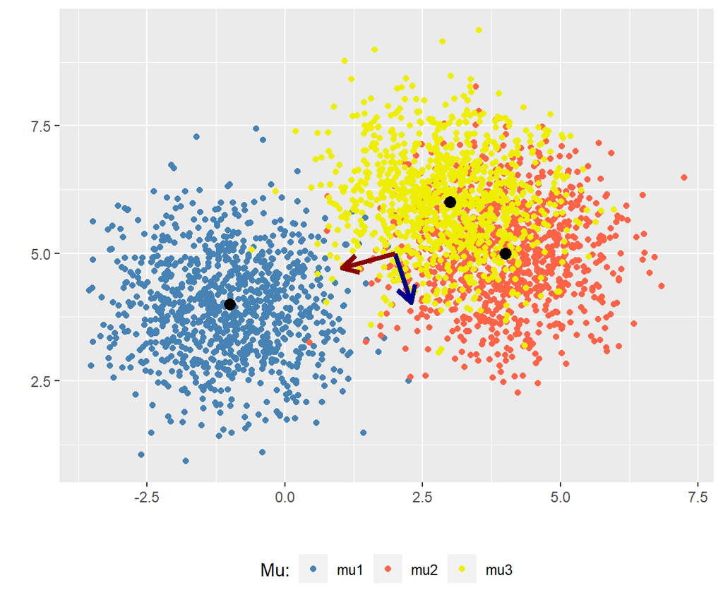

```r
ggplot(data = MR)+
  geom_point(aes(x=X1, y=X2,col="mu1"))+
  geom_point(aes(x=X1.1, y=X2.1,col="mu2"))+
  geom_point(aes(x=X1.2, y=X2.2,col="mu3"))+
  geom_point(data = mu,aes(x=mu1[1],y=mu1[2]),size=3)+
  geom_point(data = mu,aes(x=mu2[1],y=mu2[2]),size=3)+
  geom_point(data = mu,aes(x=mu3[1],y=mu3[2]),size=3)+
  geom_segment(data=Arrow, aes(x = p1[1], y = p1[2], xend = p2[1], yend = p2[2]),
               lwd=1.5,col="darkblue",arrow = arrow(length = unit(0.15,"inches")))+
  geom_segment(data=Arrow, aes(x = p12[1], y = p12[2], xend = p22[1], yend = p22[2]),
               lwd=1.5,col="darkred",arrow = arrow(length = unit(0.15,"inches")))+
  scale_color_manual(values=c(colors))+
  labs(x = "",y = "",color = "Mu:")+
  theme(legend.position='bottom')
```

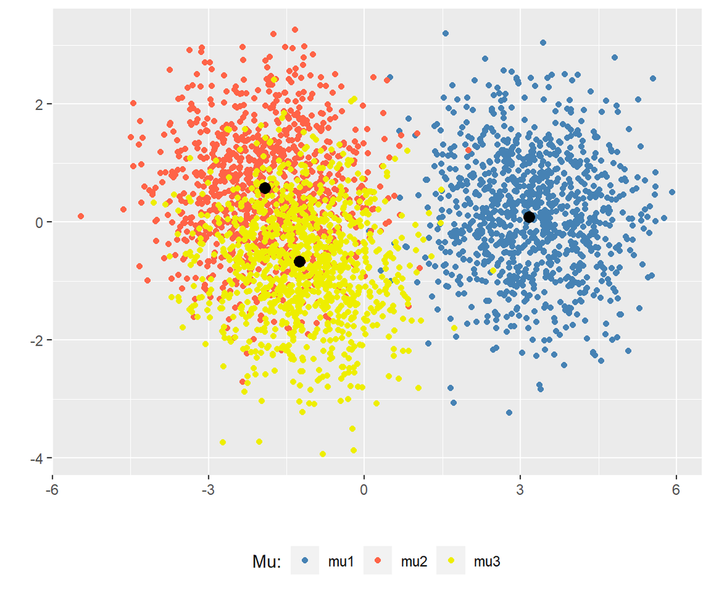

```r
ggplot(data = MRD)+
  geom_point(aes(x=X1, y=X2,col="mu1"))+
  geom_point(aes(x=X3, y=X4,col="mu2"))+
  geom_point(aes(x=X5, y=X6,col="mu3"))+
  geom_point(data = mud,aes(x=m1d,y=m1d2),size=3)+
  geom_point(data = mud,aes(x=m2d,y=m2d2),size=3)+
  geom_point(data = mud,aes(x=m3d,y=m3d2),size=3)+
  scale_color_manual(values=c(colors))+
  labs(x = "",y = "",color = "Mu:")+
  theme(legend.position='bottom')
```

In the first figure we see the data and the eigenvectors, in the second we have transformed the data using the eigenvectors. We see that the first CDF maximizes the the between group distance while the second maximizes the distance *while being uncorrelated* with the first CDF.

**4. Same question as above, but now for the case**

$$\boldsymbol{\Sigma} = \begin{bmatrix} 9 & 0 \\ 0 & 1
\end{bmatrix}$$

This amounts to solving the generalized eigenvalue problem for *B* with respect to $\boldsymbol{\Sigma} = \begin{bmatrix} 9 & 0 \\ 0 & 1\end{bmatrix}$. This is called the generalized Rayleigh quotient from theorem A.48. Using the notation from section 5.4.3:
$$W^{-1}B = \Sigma^{-1}B = \begin{bmatrix} 9 & 0 \\ 0 & 1
\end{bmatrix}^{-1} \begin{bmatrix} 14 & 4 \\ 4 & 2 \end{bmatrix}
=
\begin{bmatrix} 1/9 & 0 \\ 0 & 1 \end{bmatrix} \begin{bmatrix}
14 & 4 \\ 4 & 2 \end{bmatrix} =
\begin{bmatrix} 14/9 & 4/9 \\ 4 & 2 \end{bmatrix}$$

By straightforward calculations we obtain the eigenvalues
$$\frac{16}{9} \pm \frac{2}{9}\sqrt{37}$$

and the corresponding eigenvectors

$$s\begin{bmatrix} 1 \\ \frac{1}{2}+\frac{1}{2}\sqrt{37}\end{bmatrix} ,
t\begin{bmatrix} 1 \\ \frac{1}{2}-\frac{1}{2}\sqrt{37}\end{bmatrix}$$

where *s* and *t* are real numbers.

Our $\boldsymbol{d}_1$ is then given by the eigenvector corresponding to the largest eigenvalue (the first above), and $\boldsymbol{d}_2$ is the eigenvector corresponding to the second largest eigenvalue (the second above).

We can simulate some data and plot the eigenvectors to see what is going on:

```r
S <- matrix(c(9,0,0,1),ncol=2)

M <- 1/3 *(mu1+mu2+mu3)

B <- (mu1 - M)%*%t(mu1 - M) + (mu2 - M)%*%t(mu2 - M) + (mu3 - M)%*%t(mu3 - M)

Ev <- eigen(B)
vec <- Ev$vectors

m1r <- mvrnorm(1000,mu1,S)
m2r <- mvrnorm(1000,mu2,S)
m3r <- mvrnorm(1000,mu3,S)

p1 <- M
p2 <- M+vec[,2]
dp <- p2-p1
p12 <- M
p22 <- M+vec[,1]
dp2 <- p22-p12

MR <- data.frame(m1r,m2r,m3r)
mu <- data.frame(mu1,mu2,mu3)
Arrow <- data.frame(p1,p2,p12,p22)

m1rd <- t(vec[,1])%*%t(cbind(m1r[,1]-M[1],m1r[,2]-M[2]))
m2rd <- t(vec[,1])%*%t(cbind(m2r[,1]-M[1],m2r[,2]-M[2]))
m3rd <- t(vec[,1])%*%t(cbind(m3r[,1]-M[1],m3r[,2]-M[2]))
m1rd2 <- t(vec[,2])%*%t(cbind(m1r[,1]-M[1],m1r[,2]-M[2]))
m2rd2 <- t(vec[,2])%*%t(cbind(m2r[,1]-M[1],m2r[,2]-M[2]))
m3rd2 <- t(vec[,2])%*%t(cbind(m3r[,1]-M[1],m3r[,2]-M[2]))

m1d <- t(vec[,1])%*%(mu1-M)
m2d <- t(vec[,1])%*%(mu2-M)
m3d <- t(vec[,1])%*%(mu3-M)
m1d2 <- t(vec[,2])%*%(mu1-M)
m2d2 <- t(vec[,2])%*%(mu2-M)
m3d2 <- t(vec[,2])%*%(mu3-M)

MRD <- data.frame(t(rbind(m1rd,m1rd2,m2rd,m2rd2,m3rd,m3rd2)))
mud <- data.frame(m1d,m1d2,m2d,m2d2,m3d,m3d2)
```

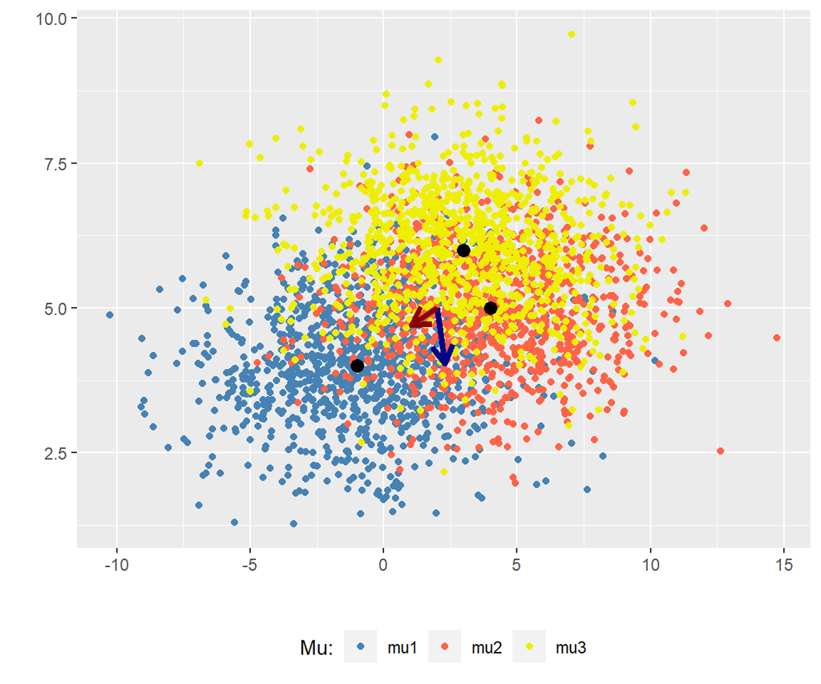

```r
ggplot(data = MR)+
  geom_point(aes(x=X1, y=X2,col="mu1"))+
  geom_point(aes(x=X1.1, y=X2.1,col="mu2"))+
  geom_point(aes(x=X1.2, y=X2.2,col="mu3"))+
  geom_point(data = mu,aes(x=mu1[1],y=mu1[2]),size=3)+
  geom_point(data = mu,aes(x=mu2[1],y=mu2[2]),size=3)+
  geom_point(data = mu,aes(x=mu3[1],y=mu3[2]),size=3)+
  geom_segment(data=Arrow, aes(x = p1[1], y = p1[2], xend = p2[1], yend = p2[2]),lwd=1.5,col="darkblue",arrow = arrow(length = unit(0.15,"inches")))+
  geom_segment(data=Arrow, aes(x = p12[1], y = p12[2], xend = p22[1], yend = p22[2]),lwd=1.5,col="darkred",arrow = arrow(length = unit(0.15,"inches")))+
  scale_color_manual(values=c(colors))+
  labs(x = "",y = "",color = "Mu:")+
  theme(legend.position='bottom')
```

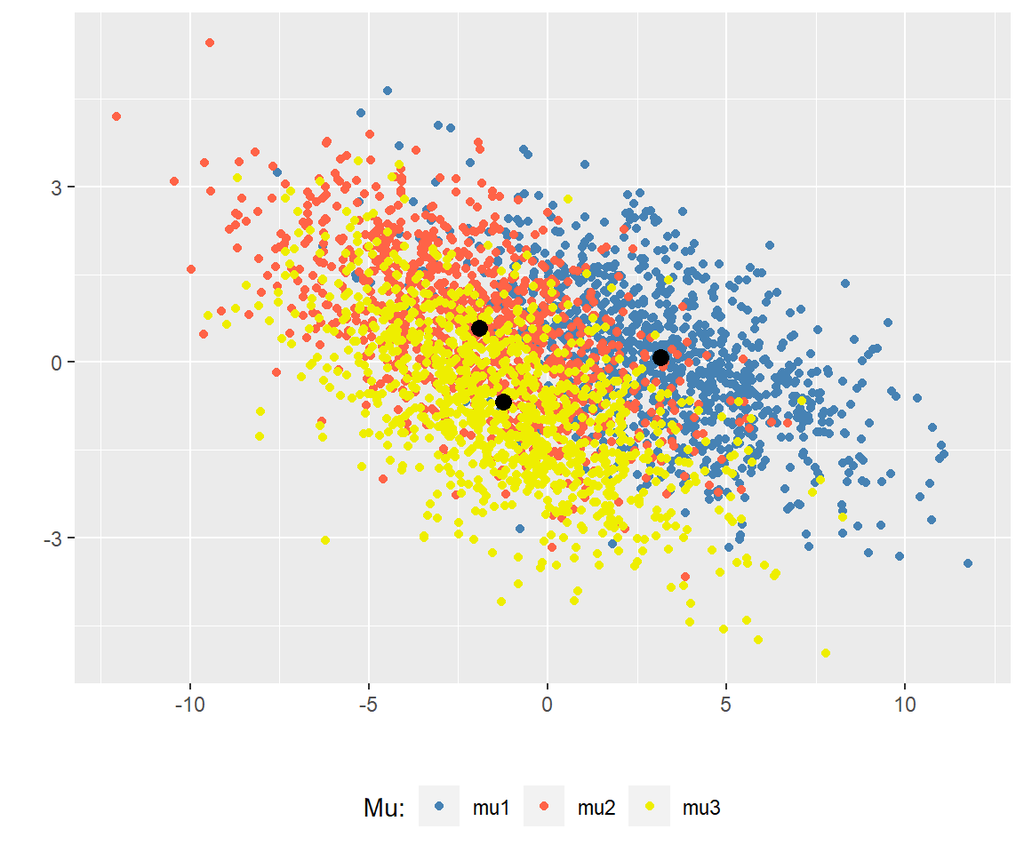

```r
ggplot(data = MRD)+
  geom_point(aes(x=X1, y=X2,col="mu1"))+
  geom_point(aes(x=X3, y=X4,col="mu2"))+
  geom_point(aes(x=X5, y=X6,col="mu3"))+
  geom_point(data = mud,aes(x=m1d,y=m1d2),size=3)+
  geom_point(data = mud,aes(x=m2d,y=m2d2),size=3)+
  geom_point(data = mud,aes(x=m3d,y=m3d2),size=3)+
  scale_color_manual(values=c(colors))+
  labs(x = "",y = "",color = "Mu:")+
  theme(legend.position='bottom')
```

An alternative solution to 3. and 4.is to do this by for e.g. using R. A program and corresponding output would be

```r
S1 <- matrix(c(1,0,0,1),ncol=2)
S2 <- matrix(c(9,0,0,1),ncol=2)

Ev1 <- eigen(B)
Ev2 <- geigen(B,S2) # eigen assumes that S = Identity matrix. So for this case use geigen.

VARG1 <- t(Ev1$vectors)%*%B%*%Ev1$vectors
VARG2 <- t(Ev2$vectors)%*%B%*%Ev2$vectors

Q3 <- cbind(B,S1,Ev1$values,Ev1$vectors,VARG1)
colnames(Q3) <- c("B","","Sigma","","lambda","D","","VARG","")
print("Question 3:")
Q3
Q4 <- cbind(B,S2,Ev2$values,Ev2$vectors,VARG2)
colnames(Q4) <- c("B","","Sigma","","lambda","D","","VARG","")
print("Question 4:")
Q4
```

```
## [1] "Question 3:"
```

```
##       B   Sigma       lambda          D                    VARG
## [1,] 14 4     1 0 15.2111026 -0.9570920  0.2897841 1.521110e+01 8.881784e-16
## [2,]  4 2     0 1  0.7888974 -0.2897841 -0.9570920 6.661338e-16 7.888974e-01
```

```
## [1] "Question 4:"
```

```
##       B   Sigma      lambda          D                   VARG
## [1,] 14 4     9 0 0.4260528 -0.2543400 0.2154583 4.260528e-01 1.110223e-16
## [2,]  4 2     0 1 3.1295028  0.6463749 0.7630200 2.220446e-16 3.129503e+00
```